# coding-assignment-1-solution

```python
import numpy as np
import pandas as pd
import matplotlib.pyplot as plt
import seaborn as sns
```

## Basic Examination

```python
# Read data: use the training set to train the model, and use the testing set to test model performance
train = pd.read_csv("train.csv")
test = pd.read_csv("test.csv")
```

```python
# Dataset size and number of features/factors
print("train shape: {}\ntest shape: {}".format(train.shape, test.shape))
```

```
train shape: (2904, 7)
test shape: (726, 6)
```

```python
# check column type, if the type is string, we may need to convert it to numerical
train.dtypes
```

```
age         float64
sex          object
bmi         float64
smoker       object
region       object
children      int64
charges     float64
dtype: object
```

```python
# Quick look at the first 5 observations
train.head(5)
```

|  | age | sex | bmi | smoker | region | children | charges |
| --- | --- | --- | --- | --- | --- | --- | --- |
| 0 | 32.725701 | female | 27.783664 | no | northwest | 3 | 5824.781630 |
| 1 | 35.944364 | female | 44.548571 | no | southeast | 3 | 6414.240703 |
| 2 | 57.000000 | female | 31.825000 | no | northwest | 0 | 11842.623750 |
| 3 | 57.000000 | male | 43.700000 | no | southwest | 1 | 11576.130000 |
| 4 | 44.272293 | female | 42.949038 | yes | southeast | 2 | 45841.468648 |

```python
# define response variable (the value of interest for the study)
response = "charges"
```

```python
# check any missing
train.isnull().sum()
```

```
age           0
sex           0
bmi         153
smoker        0
region        0
children      0
charges       0
dtype: int64
```

```python
test.isnull().sum()
```

```
age          0
sex          0
bmi         29
smoker       0
region       0
children     0
dtype: int64
```

Column *bmi* requires imputation

## 1. Preprocessing

- Impute missing values in *bmi* column (An alternative would be to drop observations with missing *bmi*.)
- One-hot encoding string variables on *sex*, *smoker*, and *region* (so they can be directly used by most models)
- (Optional) Make sure variable *age* only has integer
- (Optional) Remove outliers (for example, in case of *bmi*)

### 1.1 Imputation

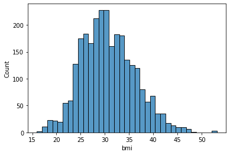

```python
# get a look at bmi distribution before imputation
plt.figure()
sns.histplot(train["bmi"])
plt.show()
```

```python
# use median to impute the missing values
bmi_nan_median = np.nanmedian(train["bmi"])
train["bmi"] = train["bmi"].fillna(bmi_nan_median)
# NOTE: need to use train mode for test imputation (to prevent data leakage)
test["bmi"] = test["bmi"].fillna(bmi_nan_median)
```

```python
train.isnull().sum()
```

```
age         0
sex         0
bmi         0
smoker      0
region      0
children    0
charges     0
dtype: int64
```

```python
test.isnull().sum()
```

```
age         0
sex         0
bmi         0
smoker      0
region      0
children    0
dtype: int64
```

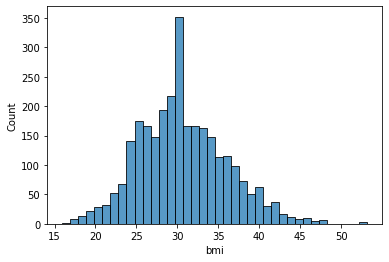

```python
# get a look at bmi distribution after imputation
plt.figure()
sns.histplot(train["bmi"])
plt.show()
```

*From the histogram of *bmi* before and after imputation using one statistics (simple imputation), the variance of the feature will be reduced. For smaller dastasets, it may be helpful to use some more complex imputation methods (e.g. multiple imputation like MICE).

### 1.2 One-Hot Encoding

```python
cat_cols = train.columns[train.dtypes == object]
cat_cols
```

```
Index(['sex', 'smoker', 'region'], dtype='object')
```

```python
# one-hot encoding
train_one_hot = pd.get_dummies(train, drop_first = True)
test_one_hot = pd.get_dummies(test, drop_first = True)
train_one_hot.shape, test_one_hot.shape
```

```
((2904, 9), (726, 8))
```

```python
# check whether columns in train/test matches
# no response in test part
set(train_one_hot.columns) - set([response]) == set(test_one_hot.columns)
```

```
True
```

There are multiple ways to convert categorical variables to numerical variables, such as using sklearn.preprocessing.OneHotEncoder and pandas.get_dummies. Be careful that the conversion should be consistent between the train and test datasets. Some machine learning models have built-in conversion, while others don't. So it's safer to have this in the data preprocessing step.

### 1.3 Convert *age* to integer

```python
train_one_hot["age"] = train_one_hot["age"].astype(int)
test_one_hot["age"] = test_one_hot["age"].astype(int)
```

Looking at *age* feature, there are some float type values (with long decimal places), which is not common. Here we convert them to integers, but in terms of statistical analysis, it's not necessary for such conversion.

### 1.4 remove extreme outliers in *bmi*

```python
train_one_hot["bmi"].describe()
```

```
count    2904.000000
mean       30.651779
std         5.356134
min        15.960000
25%        26.885000
50%        30.219855
75%        33.935706
max        53.130000
Name: bmi, dtype: float64
```

```python
train_one_hot["bmi"].nlargest(n = 10)
```

```
359     53.130000
127     52.580000
2871    52.580000
1716    48.070000
690     47.740000
1387    47.740000
873     47.600000
2781    47.520000
2137    47.410000
2443    46.986496
Name: bmi, dtype: float64
```

```python
test_one_hot["bmi"].nlargest(n = 10)
```

```
185    46.750000
430    45.430000
118    44.880000
357    44.480330
593    44.013083
599    43.853143
334    43.819978
17     43.010000
507    43.010000
206    42.598023
Name: bmi, dtype: float64
```

There are 3 *bmi* larger than 52 and the fourth largest is 48, so these may be outliers. We can remove these outliers to improve the performance.

The term outlier is usually subjective. The common practice is to ignore the outliers first, train a model, evaluate it, and if the model performance doesn't reach expectation, we will then try to apply some outlier detections. This is sometimes called winsorizing, and should be carefully documented in the analysis if it is used.

In field of insurance, there is an additional reason to not drop outliers, as we are interested in modeling the extreme cases, and those outliers may be the exact indicator of the accidents.

```python
train_one_hot = train_one_hot[train_one_hot["bmi"] < 50]
train_one_hot.shape
```

```
(2901, 9)
```

## 2. Data Exploration (EDA)

```
age :
```

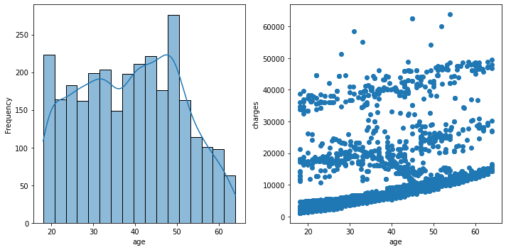

```
sex :
```

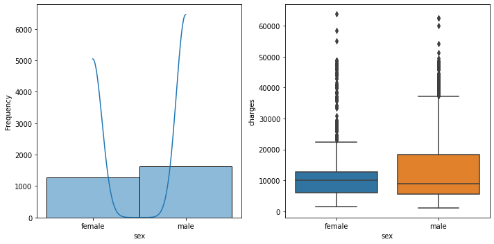

```
bmi :
```

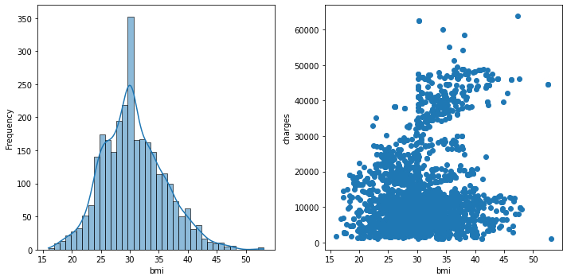

```
smoker :
```

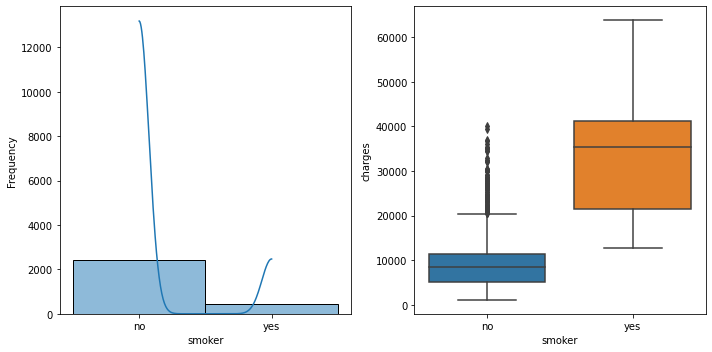

```
region :
```

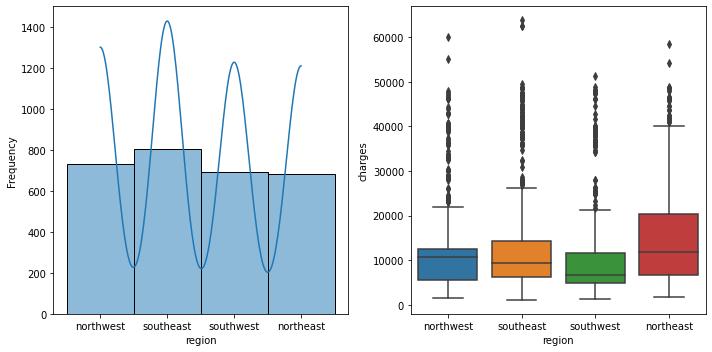

```
children :
```

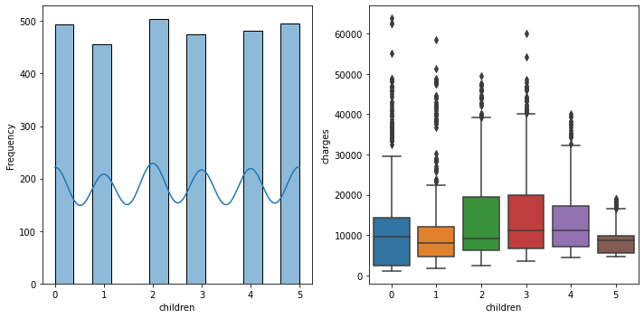

```
charges :
```

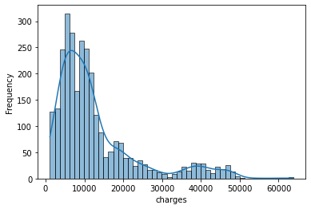

```python
# Data visualization for each explanatory variables (columns that are not the response variable)
# Their own distribution and relationship to the "charges"
# There are many ways to use data visualization to explore characteristics of the variables, correlation, and dependence
# You can also use summary statistics for data exploration

for col in train.columns:
    print("{} :".format(col))
    # for features
    if col != response :
        fig, (ax1, ax2) = plt.subplots(1, 2, figsize=(10, 5))
        # hist plot of the feature
        sns.histplot(train[col], ax = ax1, kde = True)
        ax1.set_xlabel(col)
        ax1.set_ylabel("Frequency")
        # boxplot for categorical feature
        if len(np.unique(train[col])) <= 10:
            sns.boxplot(x=col, y=response, data=train, ax=ax2)
        # scatter plot for continous feature
        else :
            ax2.scatter(train[col], train[response])
        ax2.set_xlabel(col)
        ax2.set_ylabel(response)
        plt.tight_layout()
        plt.show()
    # for
    else :
        plt.figure()
        sns.histplot(train[col], kde = True)
        plt.xlabel(col)
        plt.ylabel("Frequency")
        plt.show()
```

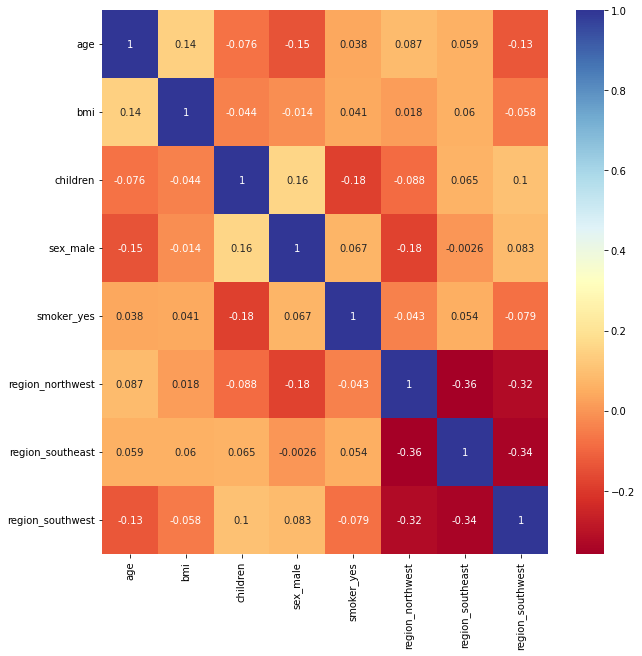

```python
# correlation matrix within features (another way to check relationships between variables)
plt.figure(figsize=(10, 10))
features = list(train_one_hot.columns)
features.remove(response)
sns.heatmap(train_one_hot[features].corr(), annot=True, cmap="RdYlBu")
plt.show()
```

```python
# correlation between features and response
for col in list(set(train_one_hot.columns) - set([response])):
    print("Corr between {:20s} and {:10s} : {:8.4f}".format(
        col, response, train_one_hot[col].corr(train_one_hot[response])
    ))
```

```
Corr between region_northwest     and charges    :  -0.0573
Corr between children             and charges    :  -0.0728
Corr between bmi                  and charges    :   0.2109
Corr between age                  and charges    :   0.3009
Corr between sex_male             and charges    :   0.0883
Corr between smoker_yes           and charges    :   0.7859
Corr between region_southwest     and charges    :  -0.1246
Corr between region_southeast     and charges    :   0.0542
```

As seen from both boxplots and correlation matrix, smoker or not is the most important feature, followed by age, bmi.